# Estimating present population based on Mobile Network Operator data - a simulation study - third draft 29.10.2020

Stefania, Giulia, Tony, Marco

```r
library(tidyverse)
library(sf)
library(raster)
library(Matrix)
library(knitr)
library(kableExtra)
library(ggthemes)
library(cowplot)

set.seed(762)
```

This exercise will be a simulation study partly based on real and simulated data from either official sources or from our own calculations. The notebook relies on multiple scripts that follow a methodological/technical chain. Each chain element can be considered as an independent module which makes it easy to change parameters in a module and follow through with the remaining chain. Therefore, multiple objects are created in advance (in an efficient manner because of parallelization) and loaded into the notebook. The objects will be explained, their parameters presented and the source code hyperlinked.

Currently three modules are implemented:

# 1 Generating a semi-synthetic population based on real census data

We have retrieved population census data from the German Federal Statistical Office on Germany (https://www.destatis.de/EN/Home/_node.html). This data entails population count categories on the 100m*100m tile level. Additional meta information such as age proportions etc. are included and will be utilized in subsequent versions. For computational reasons, this version will only focus on a subset of the tiles located in the state of Bavaria, which is situated in the south-east of Germany. We chose this area especially because it comprises both urban, suburban, and rural areas. The underlying code is written in a modular way so that once a high computing machine is available, we could easily scale this notebook to the entirety of Germany.

In the following block of code, the census data is loaded in. For further processing the pop.category-variable is created to categorize each tile in the following way: 1 = rural, 2 = suburban, and 3 = urban. These are based on the specific population value within the tile. The ranges for each category are still up to discussion.

The sample population value is used as the number of mobile phones in a specific tile and throughout in this current version of the notebook. This sample population is a direct reference to the `u` vector in the working paper. In subsequent versions, this original population value will be adjusted based on additional variables to get a more realistic count of people with mobile phones in the each tile.

The link to the source code for the `census.de.100.m.tile` object is [here](https://github.com/R-ramljak/MNO_GM/blob/master/1_Read%20in%20data.R).

```r
census.de.100m.tile <- readRDS("working objects/census.tile.final.rds")

dim(census.de.100m.tile)
```

```
## [1] 1828314       7
```

```r
class(census.de.100m.tile)
```

```
## [1] "sf"         "tbl_df"     "tbl"        "data.frame"
```

```r
census.de.100m.tile %>%
  st_drop_geometry() %>%
  sample_n(10) %>%
  # head() %>%
  kbl(caption = "Exploration of the dataset about tiles of South Bavaria") %>%
  kable_minimal()
```

Exploration of the dataset about tiles of South Bavaria

| cluster_id | internal.id | pop | pop.raster | cluster.tile.n | pop.area.kind |
| --- | --- | --- | --- | --- | --- |
| NA | 1655405 | 1 | 0 | 1820283 | Rural |
| NA | 27285 | 0 | 0 | 1820283 | Rural |
| NA | 446649 | 0 | 0 | 1820283 | Rural |
| NA | 854549 | 1 | 0 | 1820283 | Rural |
| NA | 1424554 | 4 | 0 | 1820283 | Rural |
| NA | 156411 | 0 | 0 | 1820283 | Rural |
| NA | 716334 | 1 | 0 | 1820283 | Rural |
| NA | 432782 | 1 | 0 | 1820283 | Rural |
| NA | 1034380 | 0 | 0 | 1820283 | Rural |
| NA | 1732386 | 0 | 0 | 1820283 | Rural |

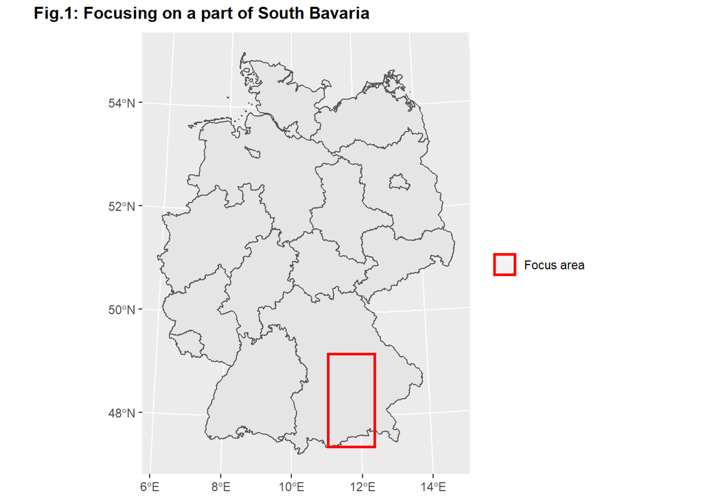

```r
# # Bounding box of focus area
 bb.focus.dat <- data.frame(xmin = 4400000, xmax = 4500000,
                            ymin = 2700000, ymax = 2900000)
 bb.focus.vec <- c(xmin = 4400000, xmax = 4500000,
                   ymin = 2700000, ymax = 2900000)

#Download data from : https://gadm.org/download_country_v3.html --> R(sf) level 1
germany.raw <- readRDS("gadm36_DEU_1_sf.rds")
germany = germany.raw %>%
  st_transform(crs=3035)

Fig.1 <- germany %>%
  ggplot() +
  geom_sf() +
  geom_rect(data = bb.focus.dat, aes(ymin = ymin, ymax = ymax,
                                      xmin = xmin, xmax = xmax,
                                     color = "red"),
            size = 1, fill = "transparent") +
  ggtitle("") +
  scale_color_identity(name = "",
                          # breaks = c("Focus area"),
                          labels = c("Focus area"),
                          guide = "legend")

plot_grid(Fig.1, labels = "Fig.1: Focusing on a part of South Bavaria",
          hjust = -0.1, label_size = 12)
```

Figure 1 shows the whole of Germany. In order to balance realistic setup and computational feasibility, we have chosen a focus area which is indicated with the red bounding box.

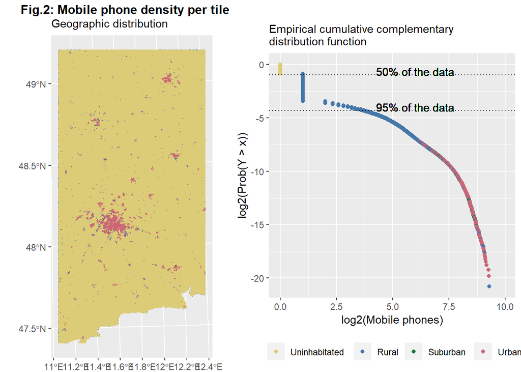

```r
# Since there is a large percentage of zeros in the tiles, we added 1 to every tile to receive valid values for the log transformation

# ECCDF of population distribution
ECCDF.data <- census.de.100m.tile %>%
  mutate(pop.plot = pop + 1) %>%
  arrange(pop.plot) %>%
  mutate(prob = 1 / n()) %>%
  mutate(cum.prob = cumsum(prob)) %>%
  mutate(log2.cum.prob.comp = log2(1 - cum.prob)) %>%
  mutate(log2.pop = log2(pop.plot)) %>%
  mutate(pop.area.kind = case_when(pop == 0 ~ "Uninhabitated",
                                   TRUE ~ pop.area.kind))
# Giulia and Stefania will change this
Fig.2.1 <- ECCDF.data %>%
  # sample_n(10000) %>%
  ggplot() +
  geom_sf(aes(color = pop.area.kind), show.legend = F) +
  scale_color_ptol(breaks = c("Uninhabitated", "Rural", "Suburban", "Urban")) +
  ggtitle("", subtitle = "Geographic distribution") +
  theme(plot.margin=unit(c(0,0,0,0),"mm"))


Fig.2.2 <- ECCDF.data %>%
  # sample_n(1000) %>%
  ggplot() +
  geom_point(aes(x = log2.pop, y = log2.cum.prob.comp,
               color = pop.area.kind)) +
  geom_hline(yintercept = -1, linetype = "dotted") +
  geom_hline(yintercept = -4.321928, linetype = "dotted") +
  geom_text(x = 6, y = -0.65, label = "50% of the data") +
  geom_text(x = 6, y = -4, label = "95% of the data") +
  scale_color_ptol(breaks = c("Uninhabitated", "Rural", "Suburban", "Urban")) +
  ggtitle("", subtitle = "Empirical cumulative complementary\ndistribution function") +
  labs(y = "log2(Prob(Y > x))", x = "log2(Mobile phones)",
        colour = "") +
  theme(legend.position="bottom")



plot_grid(Fig.2.1, Fig.2.2, labels = "Fig.2: Mobile phone density per tile",
          hjust = -0.1, label_size = 12, rel_widths = c(0.8, 1))
```

# 2 Generation of a synthetic the Radio Network

At this stage we have a focus area, which is divided into about 1,8 million 100m² tiles. Every tile is classified as either `Rural`, `Suburban` or `Urban` and for every tile there is a valid population count value available which we assume to be the tile’s respective mobile phone count.

We generate a radio network, which is composed of three layers. The layers follow the `pop.area.kind` variable - `layer 1 (Rural)` spans over the rural, suburban and urban tiles, `layer 2 (Suburban)` spans over the suburban and urban tiles and `layer 3 (Urban)` is spanned over the urban tiles.

**Important features and parameters of the generated radio network are:**

- The layers follow a hexagon shape with cell towers located in the respective centroid of each hexagon
- Each cell tower location is jittered in order to break the symmetry. The jitter amount in meters depends on the layer: `layer 1` = 5000m, `layer 2` = 1000m, `layer 3` = 400m).
- Each layer has a different cell size: `layer 1` = 35,000m; `layer 2` = 8000m; `layer 3` = 1000m (–> the more urbanized the smaller the cell –> the more towers) and hexagon independent rotation in terms of the first layer is executed: `layer 2` = 35 degrees; `layer 3` = 70 degrees
- Each tower contains three antennas pointing into 120 degree differing directions
- The layer determines the coverage diameter of an antenna: `layer 1` = 15,000m; `layer 2` = 2500m; `layer 3` = 500m
- Each tile of the focus area is covered by at least one antenna and the antennas’ coverage areas are allowed to overlap
- Parameters concerning the device to cell association are specified in the next section

The link to the source code for the layers.1 object as well as the coverage.areas.1 object is [here](https://github.com/R-ramljak/MNO_GM/blob/master/2_Radio%20cell%20generation.R).

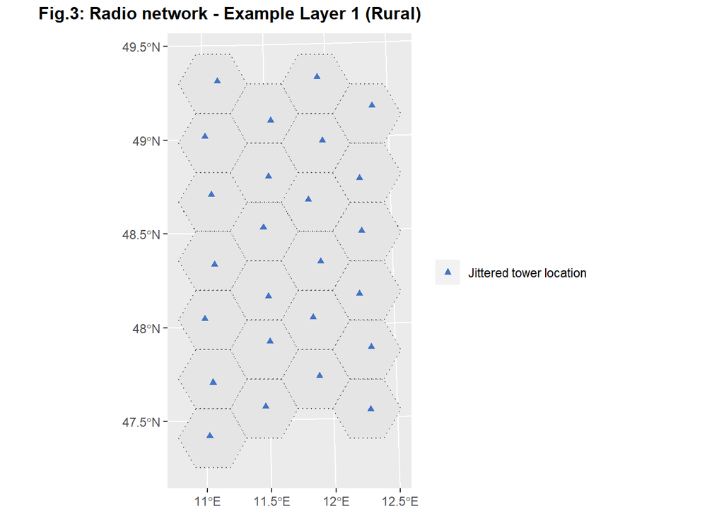

```r
layers <- readRDS("working objects/radio cell layers.rds")
coverage.areas <- readRDS("working objects/coverage.areas.rds")

coverage.layer1 <- coverage.areas %>%
  filter(area.kind == "Rural") %>%
  st_drop_geometry() %>%
  dplyr::select(-antenna.centroid) %>%
  st_as_sf(coords = c("X.tow", "Y.tow"), crs = 3035)

Fig.3 <- layers[[1]] %>%
  st_as_sf(crs = 3035) %>%
  ggplot() +
    # geom_rect(data = bb.focus.dat, aes(ymin = ymin, ymax = ymax,
    #                                   xmin = xmin, xmax = xmax),
    #         color = "black", size = 0.3, alpha = 0.5, fill = alpha("grey", 0)) +
  geom_sf(linetype = "dotted") +
  geom_sf(data = coverage.layer1, aes(color = "#4273C5"), shape = 17) +
  scale_color_identity(name = "",
                       # breaks = c("Focus area"),
                       labels = c("Jittered tower location"),
                       guide = "legend") +
  ggtitle("")

plot_grid(Fig.3, labels = "Fig.3: Radio network - Example Layer 1 (Rural)",
          hjust = -0.1, label_size = 12)
```

We use a hexagonal structure to place towers across our focus area. This is a quite realistic structure for cell towers. Each hexagon corresponds to one tower which is originally placed in the centroid of the respective hexagon. Figure 3 exemplifies the effect of the jitter parameter in the 1st layer - the actual location deviates slightly from the centroid in order to break the symmetry of the underlying hexagonal structure. This is done for every layer.

The setup of a tower with its corresponding antennas is in every layer the same: Three antennas per tower, pointing into 120 degree differing directions. The animated visualization exemplifies this for any generic tower.

[figure not shown]

```r
knitr::include_graphics("working objects/antenna animation.gif")
```

Basically, a tower is generated at its specified location, then three antennas are created. For the operationalized data structure, the antenna location is not really relevant as it corresponds to the respective tower location. What is more important are the antennas’ *coverage area centroids* because they describe the middle point of the then generated circular coverage area. The specific radius of any generic coverage area are layer specific and listed above. As indicated in the animation, an antenna specific coverage area is setup with a variable *coverage intensity profile.* Basically, cell phones that are closer to the coverage area centroid of any antenna, have a higher coverage probability, which will be later introduced as the *signal strength* parameter.

The following table presents the number of towers and the number of antennas of each layer. The number of antennas is not always a perfect factor of 3 as the coverage areas are cropped according to the focus area. This means if the complete coverage area of an antenna lies outside of the focus area it is discarded.

```r
coverage.areas %>%
  st_drop_geometry() %>%
  group_by(area.kind, tower.ID) %>%
  summarise(n.antenna = n(), .groups = "drop") %>%
  ungroup() %>%
  group_by(area.kind) %>%
  summarise(n.tower = n(),
            n.antenna = sum(n.antenna), .groups = "drop") %>%
  dplyr::select(layer = area.kind, n.tower, n.antenna) %>%
  kbl(caption = "Number of towers and antennas per layer") %>%
  kable_minimal()
```

Number of towers and antennas per layer

| layer | n.tower | n.antenna |
| --- | --- | --- |
| Rural | 25 | 69 |
| Suburban | 166 | 498 |
| Urban | 1085 | 3253 |

As described in the parameter list above, more urbanized areas are covered by either layer 2 or 3. This leads to denser networks which is presented by the higher numbers of towers and therefore higher numbers of antennas in layer 2 and 3. The reason for this is that any generic antenna can only offer signal service to a limited amount of number of mobile phones. To cover all cell phones in more urbanized areas a denser radio cell network is needed in these areas. This feature will be later introduced as the *saturation* parameter.

The following figures present the actual coverage of each layer for the focus area.

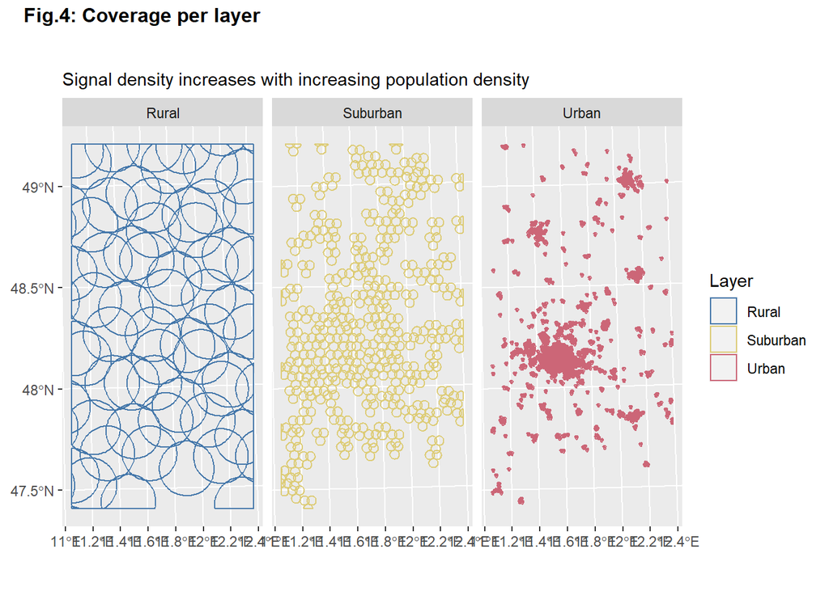

```r
Fig.4 <- coverage.areas %>%
  ggplot() +
  geom_sf(aes(col = area.kind), fill = NA) +
  facet_grid(cols = vars(area.kind)) +
  ggtitle("", subtitle = "Signal density increases with increasing population density") +
    scale_color_ptol(breaks = c("Rural", "Suburban", "Urban"), "Layer")

plot_grid(Fig.4, labels = "Fig.4: Coverage per layer",
          hjust = -0.1, label_size = 12)
```

The interpretations of the table above correspond to the level of coverage of each layer. It should be noticed that antennas’ coverage areas are allowed to overlap - within antennas of the same tower, as well as across towers of the same or another layer.

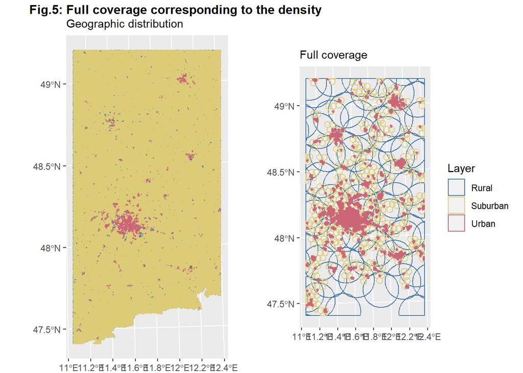

```r
# Implement shape of focus area
Fig.5 <- coverage.areas %>%
  ggplot() +
  geom_sf(aes(col = area.kind), fill = NA) +
  ggtitle("", subtitle = "Full coverage") +
    # geom_rect(data = bb.focus.dat, aes(ymin = ymin, ymax = ymax,
    #                                   xmin = xmin, xmax = xmax),
    #         color = "black", size = 0.3, alpha = 0.5, fill = alpha("grey", 0)) +
    scale_color_ptol(breaks = c("Rural", "Suburban", "Urban"), "Layer")

plot_grid(Fig.2.1, Fig.5, labels = "Fig.5: Full coverage corresponding to the density",
          hjust = -0.1, label_size = 12)
```

# 3 Device-to-cell association

*This part is under active development and due to computational difficulties a relevant code chunk is not yet implemented.*

At this stage we have added to the geographically distributed mobile phone population a radio network, which is setup in three layers, spanning respectively across tiles that correspond to specific area kinds (`pop.area.kind`).

The following module will establish the association between mobile phones of a generic tile to a relevant antenna. The result will be a reference matrix $P$ of size $I x J$, where I denotes the total number of radio cells (antennas), $J$ the total number of tiles and the elements correspond to the probability of the mobile phones of any tile $j$ are registered in the cell $i$. With $P$ one is able to simulate the column vector $c$ (random variable) which describes the total count of mobile phone associated to a radio cell.

Lets assume that $\mathcal{L}_{j}$ denotes the subset of radio cells covering a particular tile (remember, overlapping coverage areas are very common). This means that these respective radio cells are competing with each other to be associated with the cell phones in the tile. We therefore assign probabilities which describe the respective association between a radio cell $i$ and tile $j$. This probability depends on the parameter signal strength which we mimic with a simple linear function that describes the gradual decrease in signal the further away the tile centroid $j$ is from the coverage area centroid of $i$. This means, we calculate the distance between the two centroids and divide it between the radius of that radio cell - it is denoted by $s_{ij}$. We introduce a minimum threshold value $\nu$ which limits radio cells with a too low signal intensity $s_{ij}$ for a particular tile to be able to be picked up a mobile phone in that tile. This particular operationalization of a function modeling the signal strength parameter instead of fixed categorical signal strength values makes the overall workflow of the notebook more realistic (granularity) and more modular as one can later implement very easy even more realistic functions describing the signal strength parameter. The exact operationalization can be found [here](https://github.com/R-ramljak/MNO_GM/blob/master/3_device%20to%20cell.R).

The elements of $P$ - the probability with which the mobile phones within a particular cell are associated with a particular radio cell - are defined by

$$p_{ji} = \frac{s_{ij}}{\sum_{i \in \mathcal{L}_{j}} s_{ij}}$$

where $s_{ij}$ describes the signal intensity of a particular cell $i$ associated with a particular tile $j$, and $\mathcal{L}_{j}$ describes the subset of radio cells that are covering the tile $j$. We then simulate the tile specific experiments - every mobile phone within a tile will be independently assigned to relevant radio cell with the probability $p_{ij}$. The result the column vector $c$ and acts as a reference value vector for the later on introduced estimation strategies.

# 4 References

https://www.destatis.de/EN/Home/_node.html

https://github.com/R-ramljak/MNO_GM/blob/master/1_Read%20in%20data.R

https://gadm.org/download_country_v3.html

https://tma.ifip.org/2016/phdSchool/data/toy_excercise_solution.pdf